# RELATÓRIO DE ANÁLISE ESTATÍSTICA

Luciano Vaz

02/09/2026

# 1 Introdução

Este relatório apresenta uma análise estatística de um conjunto de dados referente a estudantes. O objetivo é investigar possíveis relações entre desempenho acadêmico, número de faltas, turno de estudo, escolaridade da mãe e acesso à internet.

As análises são organizadas em três etapas principais:

- análise univariada;
- análise bivariada;
- análise multivariada.

O conjunto de dados contém as seguintes variáveis:

- `faltas`: número de faltas do estudante;
- `nota_media`: nota média do estudante;
- `turno`: turno em que o estudante está matriculado;
- `escolaridade_mae`: nível de escolaridade da mãe;
- `acesso_internet`: indicação de acesso à internet.

# 2 Preparação do ambiente

```r
# Pacotes necessários
pacotes <- c("ggplot2", "knitr")

# Instala somente os pacotes que ainda não estão instalados
instalar <- pacotes[!(pacotes %in% rownames(installed.packages()))]

if (length(instalar) > 0) {
  install.packages(
    instalar,
    repos = "https://cloud.r-project.org"
  )
}

library(ggplot2)
library(knitr)

options(stringsAsFactors = FALSE)
```

# 3 Importação dos dados

O arquivo utilizado nesta análise deve se chamar `dados_alunos.csv`.

O código abaixo tenta inicialmente realizar a leitura no formato mais comum de arquivos CSV utilizados no Brasil, com `;` como separador e `,` como separador decimal.

```r
arquivo <- "dados_alunos.csv"

# Verifica se o arquivo existe
if (!file.exists(arquivo)) {
  stop(
    "O arquivo 'dados_alunos.csv' não foi encontrado. ",
    "Coloque o arquivo CSV na mesma pasta do arquivo index.Rmd."
  )
}

# Tenta ler como CSV brasileiro
dados_alunos <- tryCatch(
  read.csv2(
    arquivo,
    header = TRUE,
    stringsAsFactors = FALSE,
    check.names = FALSE,
    na.strings = c("", "NA", "NaN")
  ),
  error = function(e) NULL
)

# Variáveis esperadas
variaveis_esperadas <- c(
  "faltas",
  "nota_media",
  "turno",
  "escolaridade_mae",
  "acesso_internet"
)

# Se a primeira leitura não funcionar,
# tenta o formato CSV convencional
if (
  is.null(dados_alunos) ||
  !all(variaveis_esperadas %in% names(dados_alunos))
) {

  dados_alunos <- read.csv(
    arquivo,
    header = TRUE,
    stringsAsFactors = FALSE,
    check.names = FALSE,
    na.strings = c("", "NA", "NaN")
  )
}

# Confere se todas as variáveis existem
if (!all(variaveis_esperadas %in% names(dados_alunos))) {

  stop(
    "As colunas esperadas não foram encontradas no arquivo CSV.\n\n",
    "Colunas encontradas: ",
    paste(names(dados_alunos), collapse = ", "),
    "\n\nColunas esperadas: ",
    paste(variaveis_esperadas, collapse = ", ")
  )
}
```

# 4 Tratamento das variáveis

Nesta etapa, as variáveis quantitativas são convertidas para formato numérico e as variáveis qualitativas são transformadas em fatores.

```r
# Variáveis quantitativas
dados_alunos$faltas <- as.numeric(
  gsub(
    ",",
    ".",
    as.character(dados_alunos$faltas),
    fixed = TRUE
  )
)

dados_alunos$nota_media <- as.numeric(
  gsub(
    ",",
    ".",
    as.character(dados_alunos$nota_media),
    fixed = TRUE
  )
)

# Variável turno
dados_alunos$turno <- factor(
  trimws(as.character(dados_alunos$turno)),
  levels = c(
    "Matutino",
    "Vespertino",
    "Noturno"
  )
)

# Escolaridade da mãe
dados_alunos$escolaridade_mae <- factor(
  trimws(as.character(dados_alunos$escolaridade_mae)),
  levels = c(
    "Fundamental",
    "Médio",
    "Superior"
  ),
  ordered = TRUE
)

# Acesso à internet
dados_alunos$acesso_internet <- factor(
  trimws(as.character(dados_alunos$acesso_internet)),
  levels = c(
    "Não",
    "Sim"
  )
)
```

# 5 Conhecendo o banco de dados

```r
# Primeiras observações
head(dados_alunos)
```

|  | faltas | nota_media | turno | escolaridade_mae | acesso_internet |
| --- | --- | --- | --- | --- | --- |
| 1 | 11 | 10.0 | Vespertino | Médio | Sim |
| 2 | 8 | 8.3 | Matutino | Fundamental | Sim |
| 3 | 9 | 9.2 | Vespertino | Fundamental | Sim |
| 4 | 7 | 5.8 | Matutino | Médio | Sim |
| 5 | 7 | 8.6 | Vespertino | Fundamental | Não |
| 6 | 16 | 5.3 | Vespertino | Médio | Sim |

```r
# Dimensões do banco
dim(dados_alunos)
```

```
## [1] 1000    5
```

```r
# Estrutura das variáveis
str(dados_alunos)
```

```
## 'data.frame':    1000 obs. of  5 variables:
##  $ faltas          : num  11 8 9 7 7 16 12 7 8 7 ...
##  $ nota_media      : num  10 8.3 9.2 5.8 8.6 5.3 7.8 6.7 5.5 7.3 ...
##  $ turno           : Factor w/ 3 levels "Matutino","Vespertino",..: 2 1 2 1 2 2 1 2 1 3 ...
##  $ escolaridade_mae: Ord.factor w/ 3 levels "Fundamental"<..: 2 1 1 2 1 2 1 1 2 2 ...
##  $ acesso_internet : Factor w/ 2 levels "Não","Sim": 2 2 2 2 1 2 2 1 2 2 ...
```

# 6 Valores ausentes

A quantidade de valores ausentes em cada variável é apresentada abaixo.

```r
colSums(is.na(dados_alunos))
```

```
##           faltas       nota_media            turno escolaridade_mae
##                0                0                0                0
##  acesso_internet
##                0
```

# 7 Estatística descritiva

## 7.1 Número de faltas

As principais estatísticas descritivas do número de faltas são calculadas a seguir.

```r
estatisticas_faltas <- data.frame(
  Estatistica = c(
    "Mínimo",
    "1º Quartil",
    "Mediana",
    "Média",
    "3º Quartil",
    "Máximo",
    "Desvio-padrão"
  ),
  Valor = c(
    min(dados_alunos$faltas, na.rm = TRUE),
    quantile(dados_alunos$faltas, 0.25, na.rm = TRUE),
    median(dados_alunos$faltas, na.rm = TRUE),
    mean(dados_alunos$faltas, na.rm = TRUE),
    quantile(dados_alunos$faltas, 0.75, na.rm = TRUE),
    max(dados_alunos$faltas, na.rm = TRUE),
    sd(dados_alunos$faltas, na.rm = TRUE)
  )
)

kable(
  estatisticas_faltas,
  digits = 2,
  caption = "Estatísticas descritivas do número de faltas"
)
```

Estatísticas descritivas do número de faltas

| Estatistica | Valor |
| --- | --- |
| Mínimo | 1.00 |
| 1º Quartil | 6.00 |
| Mediana | 8.00 |
| Média | 8.01 |
| 3º Quartil | 10.00 |
| Máximo | 19.00 |
| Desvio-padrão | 2.80 |

## 7.2 Nota média

```r
estatisticas_notas <- data.frame(
  Estatistica = c(
    "Mínimo",
    "1º Quartil",
    "Mediana",
    "Média",
    "3º Quartil",
    "Máximo",
    "Desvio-padrão"
  ),
  Valor = c(
    min(dados_alunos$nota_media, na.rm = TRUE),
    quantile(dados_alunos$nota_media, 0.25, na.rm = TRUE),
    median(dados_alunos$nota_media, na.rm = TRUE),
    mean(dados_alunos$nota_media, na.rm = TRUE),
    quantile(dados_alunos$nota_media, 0.75, na.rm = TRUE),
    max(dados_alunos$nota_media, na.rm = TRUE),
    sd(dados_alunos$nota_media, na.rm = TRUE)
  )
)

kable(
  estatisticas_notas,
  digits = 2,
  caption = "Estatísticas descritivas das notas"
)
```

Estatísticas descritivas das notas

| Estatistica | Valor |
| --- | --- |
| Mínimo | 0.50 |
| 1º Quartil | 5.20 |
| Mediana | 6.50 |
| Média | 6.44 |
| 3º Quartil | 7.70 |
| Máximo | 10.00 |
| Desvio-padrão | 1.88 |

# 8 Distribuição das faltas

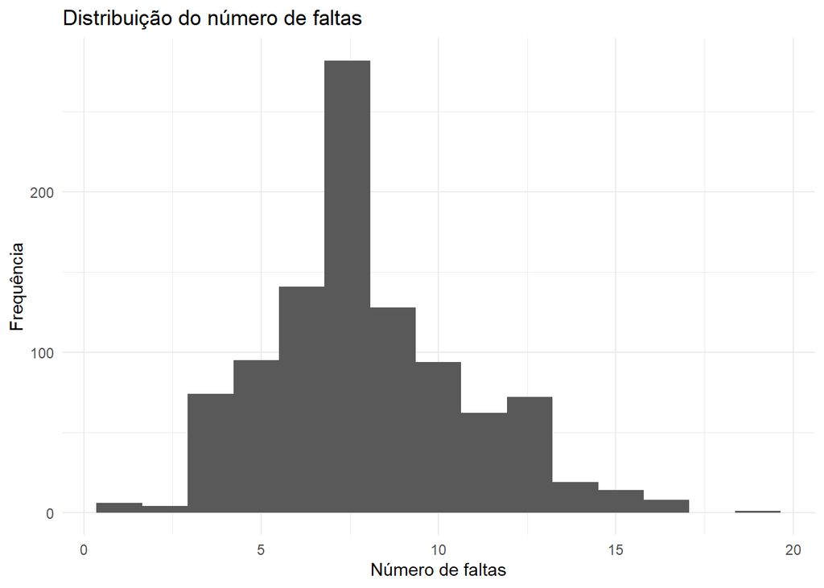

```r
ggplot(
  dados_alunos,
  aes(x = faltas)
) +
  geom_histogram(
    bins = 15,
    na.rm = TRUE
  ) +
  labs(
    title = "Distribuição do número de faltas",
    x = "Número de faltas",
    y = "Frequência"
  ) +
  theme_minimal()
```

# 9 Distribuição das notas

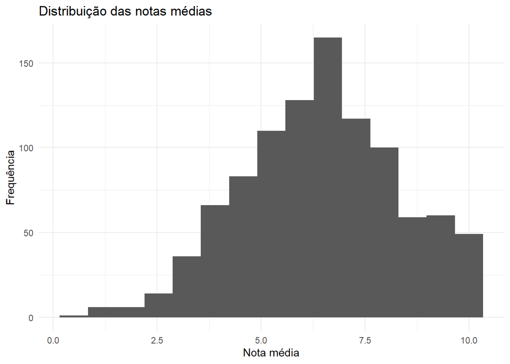

```r
ggplot(
  dados_alunos,
  aes(x = nota_media)
) +
  geom_histogram(
    bins = 15,
    na.rm = TRUE
  ) +
  labs(
    title = "Distribuição das notas médias",
    x = "Nota média",
    y = "Frequência"
  ) +
  theme_minimal()
```

# 10 Análise das variáveis qualitativas

## 10.1 Distribuição por turno

```r
frequencia_turno <- as.data.frame(
  table(dados_alunos$turno, useNA = "ifany")
)

names(frequencia_turno) <- c(
  "Turno",
  "Frequencia"
)

frequencia_turno$Percentual <- round(
  100 *
    frequencia_turno$Frequencia /
    sum(frequencia_turno$Frequencia),
  2
)

kable(
  frequencia_turno,
  caption = "Distribuição dos estudantes por turno"
)
```

Distribuição dos estudantes por turno

| Turno | Frequencia | Percentual |
| --- | --- | --- |
| Matutino | 451 | 45.1 |
| Vespertino | 345 | 34.5 |
| Noturno | 204 | 20.4 |

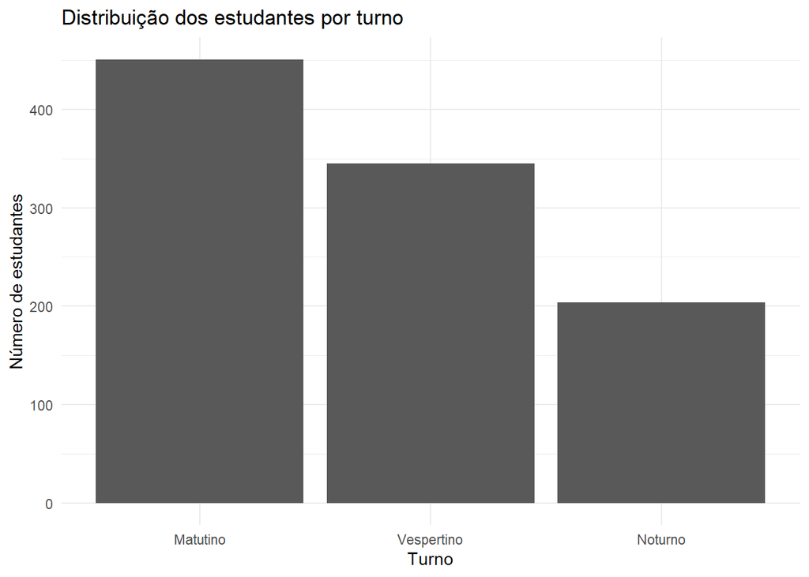

```r
ggplot(
  dados_alunos,
  aes(x = turno)
) +
  geom_bar(
    na.rm = TRUE
  ) +
  labs(
    title = "Distribuição dos estudantes por turno",
    x = "Turno",
    y = "Número de estudantes"
  ) +
  theme_minimal()
```

## 10.2 Escolaridade da mãe

```r
frequencia_mae <- as.data.frame(
  table(
    dados_alunos$escolaridade_mae,
    useNA = "ifany"
  )
)

names(frequencia_mae) <- c(
  "Escolaridade",
  "Frequencia"
)

frequencia_mae$Percentual <- round(
  100 *
    frequencia_mae$Frequencia /
    sum(frequencia_mae$Frequencia),
  2
)

kable(
  frequencia_mae,
  caption = "Escolaridade das mães dos estudantes"
)
```

Escolaridade das mães dos estudantes

| Escolaridade | Frequencia | Percentual |
| --- | --- | --- |
| Fundamental | 391 | 39.1 |
| Médio | 459 | 45.9 |
| Superior | 150 | 15.0 |

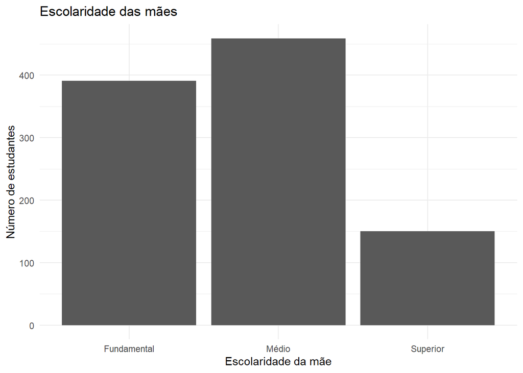

```r
ggplot(
  dados_alunos,
  aes(x = escolaridade_mae)
) +
  geom_bar(
    na.rm = TRUE
  ) +
  labs(
    title = "Escolaridade das mães",
    x = "Escolaridade da mãe",
    y = "Número de estudantes"
  ) +
  theme_minimal()
```

## 10.3 Acesso à internet

```r
frequencia_internet <- as.data.frame(
  table(
    dados_alunos$acesso_internet,
    useNA = "ifany"
  )
)

names(frequencia_internet) <- c(
  "Acesso",
  "Frequencia"
)

frequencia_internet$Percentual <- round(
  100 *
    frequencia_internet$Frequencia /
    sum(frequencia_internet$Frequencia),
  2
)

kable(
  frequencia_internet,
  caption = "Acesso à internet"
)
```

Acesso à internet

| Acesso | Frequencia | Percentual |
| --- | --- | --- |
| Não | 297 | 29.7 |
| Sim | 703 | 70.3 |

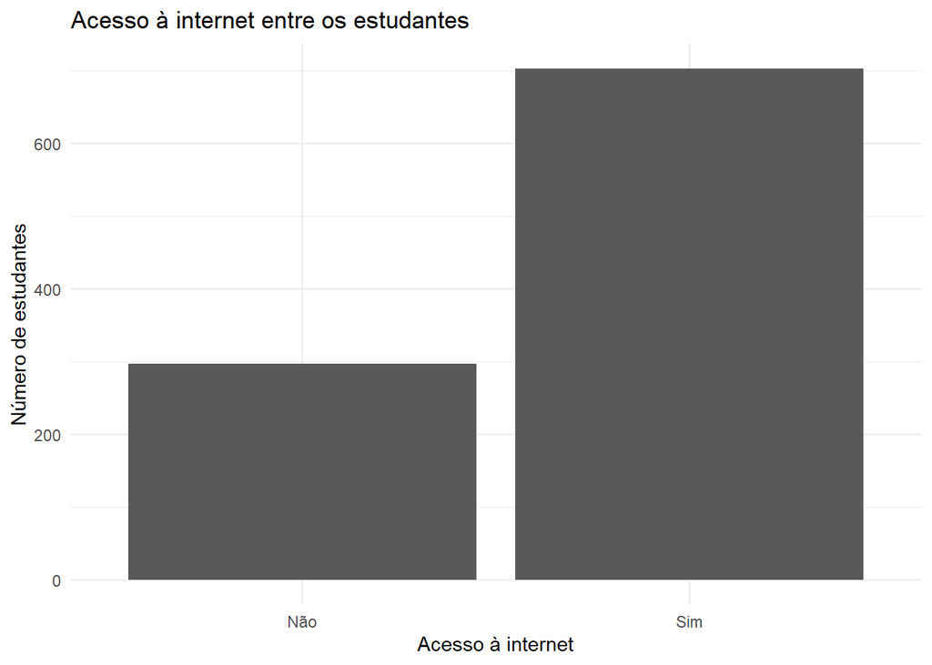

```r
ggplot(
  dados_alunos,
  aes(x = acesso_internet)
) +
  geom_bar(
    na.rm = TRUE
  ) +
  labs(
    title = "Acesso à internet entre os estudantes",
    x = "Acesso à internet",
    y = "Número de estudantes"
  ) +
  theme_minimal()
```

# 11 Internet e desempenho acadêmico

Uma das questões centrais da análise é verificar se existe diferença nas notas médias entre estudantes que possuem e não possuem acesso à internet.

## 11.1 Estatísticas por acesso à internet

```r
media_internet <- aggregate(
  nota_media ~ acesso_internet,
  data = dados_alunos,
  FUN = function(x) {
    c(
      Media = mean(x, na.rm = TRUE),
      Mediana = median(x, na.rm = TRUE),
      DesvioPadrao = sd(x, na.rm = TRUE),
      N = sum(!is.na(x))
    )
  }
)

resultado_internet <- data.frame(
  Acesso = media_internet$acesso_internet,
  Media = media_internet$nota_media[, "Media"],
  Mediana = media_internet$nota_media[, "Mediana"],
  DesvioPadrao = media_internet$nota_media[, "DesvioPadrao"],
  N = media_internet$nota_media[, "N"]
)

kable(
  resultado_internet,
  digits = 2,
  caption = "Desempenho acadêmico segundo acesso à internet"
)
```

Desempenho acadêmico segundo acesso à internet

| Acesso | Media | Mediana | DesvioPadrao | N |
| --- | --- | --- | --- | --- |
| Não | 6.48 | 6.5 | 1.90 | 297 |
| Sim | 6.43 | 6.5 | 1.87 | 703 |

## 11.2 Boxplot das notas

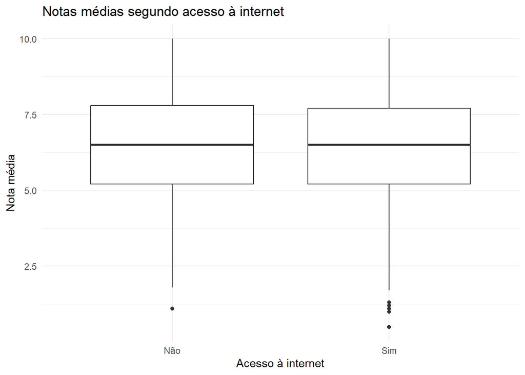

```r
ggplot(
  dados_alunos,
  aes(
    x = acesso_internet,
    y = nota_media
  )
) +
  geom_boxplot(
    na.rm = TRUE
  ) +
  labs(
    title = "Notas médias segundo acesso à internet",
    x = "Acesso à internet",
    y = "Nota média"
  ) +
  theme_minimal()
```

## 11.3 Teste t

O teste t de Welch é utilizado para verificar se as médias dos dois grupos apresentam diferença estatisticamente significativa.

```r
dados_t <- dados_alunos[
  !is.na(dados_alunos$nota_media) &
    !is.na(dados_alunos$acesso_internet),
]

teste_t <- t.test(
  nota_media ~ acesso_internet,
  data = dados_t
)

teste_t
```

```
##
##  Welch Two Sample t-test
##
## data:  nota_media by acesso_internet
## t = 0.41236, df = 549.34, p-value = 0.6802
## alternative hypothesis: true difference in means between group Não and group Sim is not equal to 0
## 95 percent confidence interval:
##  -0.2035329  0.3116928
## sample estimates:
## mean in group Não mean in group Sim
##          6.481818          6.427738
```

# 12 Escolaridade da mãe e desempenho acadêmico

Nesta seção é analisada a relação entre escolaridade da mãe e nota média dos estudantes.

## 12.1 Estatísticas por escolaridade

```r
media_mae <- aggregate(
  nota_media ~ escolaridade_mae,
  data = dados_alunos,
  FUN = function(x) {
    c(
      Media = mean(x, na.rm = TRUE),
      Mediana = median(x, na.rm = TRUE),
      DesvioPadrao = sd(x, na.rm = TRUE),
      N = sum(!is.na(x))
    )
  }
)

resultado_mae <- data.frame(
  Escolaridade = media_mae$escolaridade_mae,
  Media = media_mae$nota_media[, "Media"],
  Mediana = media_mae$nota_media[, "Mediana"],
  DesvioPadrao = media_mae$nota_media[, "DesvioPadrao"],
  N = media_mae$nota_media[, "N"]
)

kable(
  resultado_mae,
  digits = 2,
  caption = "Notas segundo escolaridade da mãe"
)
```

Notas segundo escolaridade da mãe

| Escolaridade | Media | Mediana | DesvioPadrao | N |
| --- | --- | --- | --- | --- |
| Fundamental | 6.33 | 6.5 | 1.85 | 391 |
| Médio | 6.55 | 6.5 | 1.85 | 459 |
| Superior | 6.41 | 6.2 | 2.05 | 150 |

## 12.2 Boxplot

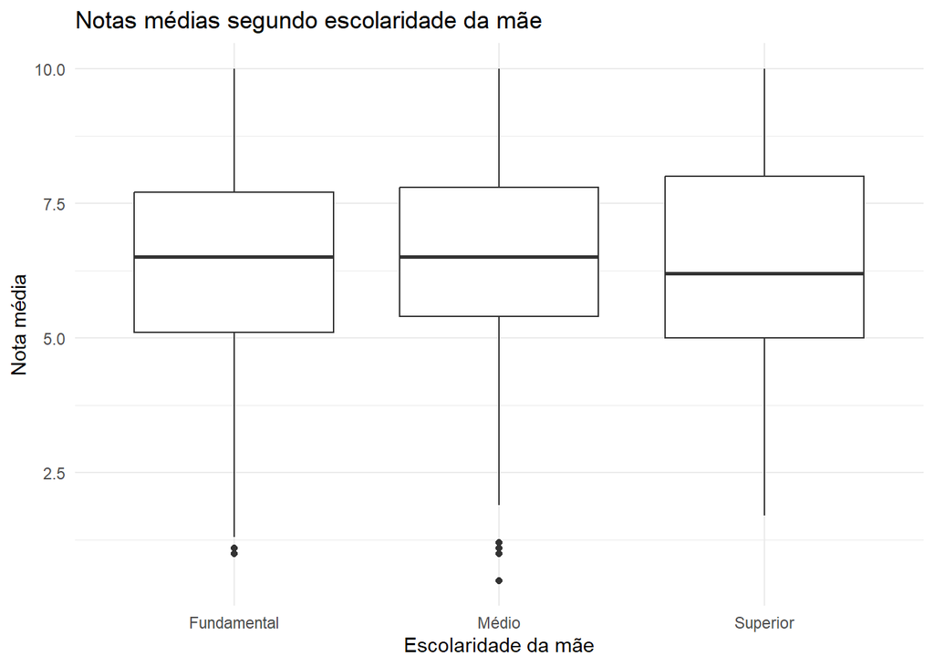

```r
ggplot(
  dados_alunos,
  aes(
    x = escolaridade_mae,
    y = nota_media
  )
) +
  geom_boxplot(
    na.rm = TRUE
  ) +
  labs(
    title = "Notas médias segundo escolaridade da mãe",
    x = "Escolaridade da mãe",
    y = "Nota média"
  ) +
  theme_minimal()
```

## 12.3 ANOVA

```r
dados_anova_mae <- dados_alunos[
  !is.na(dados_alunos$nota_media) &
    !is.na(dados_alunos$escolaridade_mae),
]

modelo_anova_mae <- aov(
  nota_media ~ escolaridade_mae,
  data = dados_anova_mae
)

summary(modelo_anova_mae)
```

```
##                   Df Sum Sq Mean Sq F value Pr(>F)
## escolaridade_mae   2     11   5.478   1.547  0.213
## Residuals        997   3529   3.540
```

# 13 Faltas e desempenho acadêmico

Nesta seção é analisada a relação entre número de faltas e nota média.

## 13.1 Correlação de Pearson

```r
dados_cor <- dados_alunos[
  !is.na(dados_alunos$faltas) &
    !is.na(dados_alunos$nota_media),
]

cor_pearson <- cor.test(
  dados_cor$faltas,
  dados_cor$nota_media,
  method = "pearson"
)

cor_pearson
```

```
##
##  Pearson's product-moment correlation
##
## data:  dados_cor$faltas and dados_cor$nota_media
## t = -0.31796, df = 998, p-value = 0.7506
## alternative hypothesis: true correlation is not equal to 0
## 95 percent confidence interval:
##  -0.07201234  0.05196132
## sample estimates:
##         cor
## -0.01006418
```

## 13.2 Correlação de Spearman

```r
cor_spearman <- cor.test(
  dados_cor$faltas,
  dados_cor$nota_media,
  method = "spearman",
  exact = FALSE
)

cor_spearman
```

```
##
##  Spearman's rank correlation rho
##
## data:  dados_cor$faltas and dados_cor$nota_media
## S = 164756910, p-value = 0.7174
## alternative hypothesis: true rho is not equal to 0
## sample estimates:
##        rho
## 0.01145755
```

## 13.3 Relação entre faltas e notas

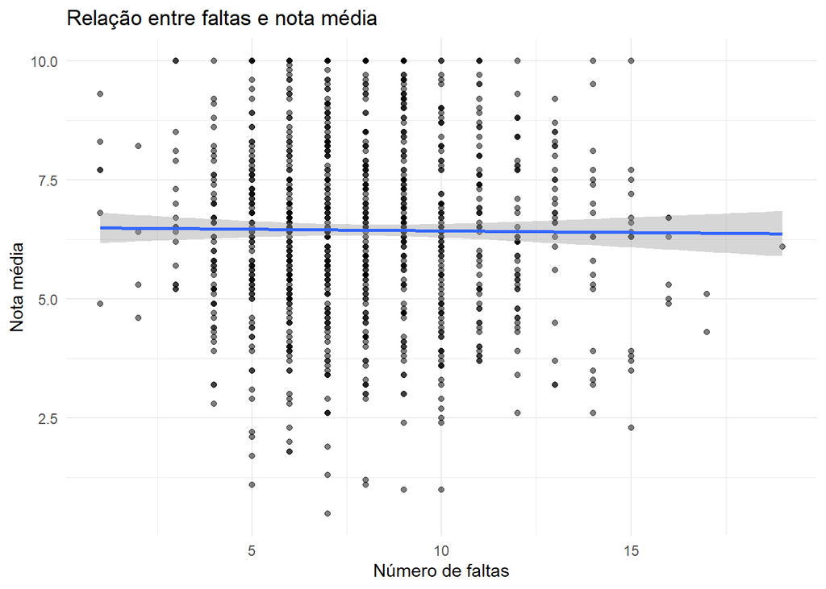

```r
ggplot(
  dados_cor,
  aes(
    x = faltas,
    y = nota_media
  )
) +
  geom_point(
    alpha = 0.5
  ) +
  geom_smooth(
    method = "lm",
    se = TRUE
  ) +
  labs(
    title = "Relação entre faltas e nota média",
    x = "Número de faltas",
    y = "Nota média"
  ) +
  theme_minimal()
```

# 14 Faixas de faltas

Para facilitar a interpretação, os estudantes são divididos em quatro grupos de faltas:

- 0 a 5 faltas;
- 6 a 8 faltas;
- 9 a 10 faltas;
- 11 ou mais faltas.

```r
dados_alunos$faixa_faltas <- cut(
  dados_alunos$faltas,
  breaks = c(
    -Inf,
    5,
    8,
    10,
    Inf
  ),
  labels = c(
    "0-5",
    "6-8",
    "9-10",
    "11+"
  ),
  right = TRUE
)
```

## 14.1 Estatísticas por faixa

```r
estatisticas_faixa <- aggregate(
  nota_media ~ faixa_faltas,
  data = dados_alunos,
  FUN = function(x) {
    c(
      Media = mean(x, na.rm = TRUE),
      Mediana = median(x, na.rm = TRUE),
      N = sum(!is.na(x))
    )
  }
)

resultado_faixa <- data.frame(
  Faixa = estatisticas_faixa$faixa_faltas,
  Media = estatisticas_faixa$nota_media[, "Media"],
  Mediana = estatisticas_faixa$nota_media[, "Mediana"],
  N = estatisticas_faixa$nota_media[, "N"]
)

kable(
  resultado_faixa,
  digits = 2,
  caption = "Notas médias segundo faixa de faltas"
)
```

Notas médias segundo faixa de faltas

| Faixa | Media | Mediana | N |
| --- | --- | --- | --- |
| 0-5 | 6.37 | 6.4 | 179 |
| 6-8 | 6.42 | 6.4 | 423 |
| 9-10 | 6.56 | 6.6 | 222 |
| 11+ | 6.42 | 6.5 | 176 |

# 15 Perfil dos estudantes do turno noturno

Nesta seção é analisado o perfil dos estudantes matriculados no período noturno.

## 15.1 Quantidade de estudantes no turno noturno

```r
noturno <- dados_alunos[
  dados_alunos$turno == "Noturno" &
    !is.na(dados_alunos$turno),
]

n_noturno <- nrow(noturno)

n_noturno
```

```
## [1] 204
```

## 15.2 Estatísticas dos estudantes do noturno

```r
estatisticas_noturno <- data.frame(
  Variavel = c(
    "Número de estudantes",
    "Média de faltas",
    "Mediana de faltas",
    "Média das notas",
    "Mediana das notas"
  ),
  Valor = c(
    nrow(noturno),
    mean(noturno$faltas, na.rm = TRUE),
    median(noturno$faltas, na.rm = TRUE),
    mean(noturno$nota_media, na.rm = TRUE),
    median(noturno$nota_media, na.rm = TRUE)
  )
)

kable(
  estatisticas_noturno,
  digits = 2,
  caption = "Perfil quantitativo dos estudantes do turno noturno"
)
```

Perfil quantitativo dos estudantes do turno noturno

| Variavel | Valor |
| --- | --- |
| Número de estudantes | 204.00 |
| Média de faltas | 7.95 |
| Mediana de faltas | 8.00 |
| Média das notas | 6.58 |
| Mediana das notas | 6.70 |

## 15.3 Acesso à internet no turno noturno

```r
tabela_noturno_internet <- table(
  noturno$acesso_internet,
  useNA = "ifany"
)

tabela_noturno_internet
```

```
##
## Não Sim
##  57 147
```

## 15.4 Escolaridade das mães dos estudantes do noturno

```r
tabela_noturno_mae <- table(
  noturno$escolaridade_mae,
  useNA = "ifany"
)

tabela_noturno_mae
```

```
##
## Fundamental       Médio    Superior
##          91          95          18
```

# 16 Comparação entre os turnos

## 16.1 Notas por turno

```r
media_turno <- aggregate(
  nota_media ~ turno,
  data = dados_alunos,
  FUN = function(x) {
    c(
      Media = mean(x, na.rm = TRUE),
      Mediana = median(x, na.rm = TRUE),
      DesvioPadrao = sd(x, na.rm = TRUE),
      N = sum(!is.na(x))
    )
  }
)

resultado_turno <- data.frame(
  Turno = media_turno$turno,
  Media = media_turno$nota_media[, "Media"],
  Mediana = media_turno$nota_media[, "Mediana"],
  DesvioPadrao = media_turno$nota_media[, "DesvioPadrao"],
  N = media_turno$nota_media[, "N"]
)

kable(
  resultado_turno,
  digits = 2,
  caption = "Desempenho acadêmico segundo turno"
)
```

Desempenho acadêmico segundo turno

| Turno | Media | Mediana | DesvioPadrao | N |
| --- | --- | --- | --- | --- |
| Matutino | 6.46 | 6.5 | 1.85 | 451 |
| Vespertino | 6.34 | 6.4 | 1.89 | 345 |
| Noturno | 6.58 | 6.7 | 1.94 | 204 |

## 16.2 Boxplot das notas por turno

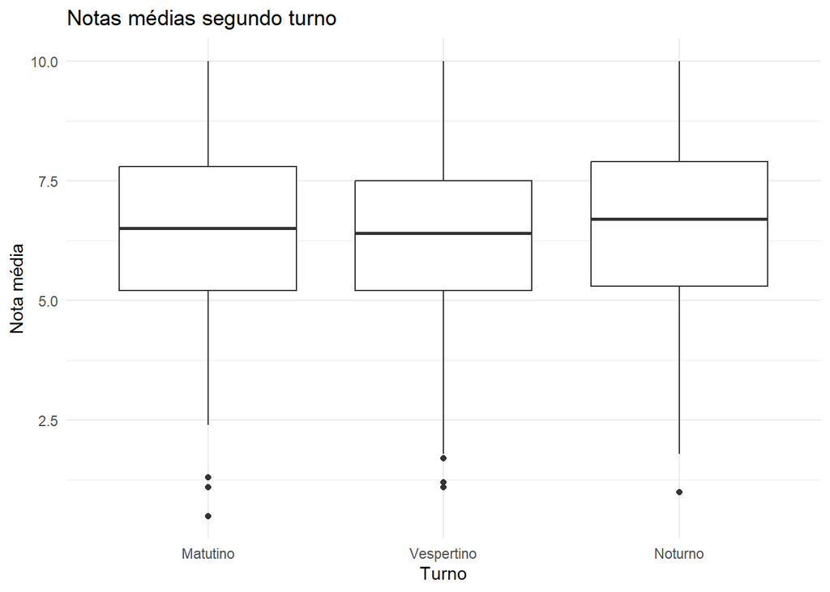

```r
ggplot(
  dados_alunos,
  aes(
    x = turno,
    y = nota_media
  )
) +
  geom_boxplot(
    na.rm = TRUE
  ) +
  labs(
    title = "Notas médias segundo turno",
    x = "Turno",
    y = "Nota média"
  ) +
  theme_minimal()
```

## 16.3 ANOVA das notas por turno

```r
dados_anova_turno <- dados_alunos[
  !is.na(dados_alunos$nota_media) &
    !is.na(dados_alunos$turno),
]

modelo_anova_turno <- aov(
  nota_media ~ turno,
  data = dados_anova_turno
)

summary(modelo_anova_turno)
```

```
##              Df Sum Sq Mean Sq F value Pr(>F)
## turno         2      8   4.051   1.144  0.319
## Residuals   997   3532   3.543
```

# 17 Faltas segundo o turno

```r
media_faltas_turno <- aggregate(
  faltas ~ turno,
  data = dados_alunos,
  FUN = function(x) {
    c(
      Media = mean(x, na.rm = TRUE),
      Mediana = median(x, na.rm = TRUE),
      DesvioPadrao = sd(x, na.rm = TRUE),
      N = sum(!is.na(x))
    )
  }
)

resultado_faltas_turno <- data.frame(
  Turno = media_faltas_turno$turno,
  Media = media_faltas_turno$faltas[, "Media"],
  Mediana = media_faltas_turno$faltas[, "Mediana"],
  DesvioPadrao = media_faltas_turno$faltas[, "DesvioPadrao"],
  N = media_faltas_turno$faltas[, "N"]
)

kable(
  resultado_faltas_turno,
  digits = 2,
  caption = "Número de faltas segundo turno"
)
```

Número de faltas segundo turno

| Turno | Media | Mediana | DesvioPadrao | N |
| --- | --- | --- | --- | --- |
| Matutino | 8.03 | 8 | 2.78 | 451 |
| Vespertino | 8.03 | 8 | 2.91 | 345 |
| Noturno | 7.95 | 8 | 2.65 | 204 |

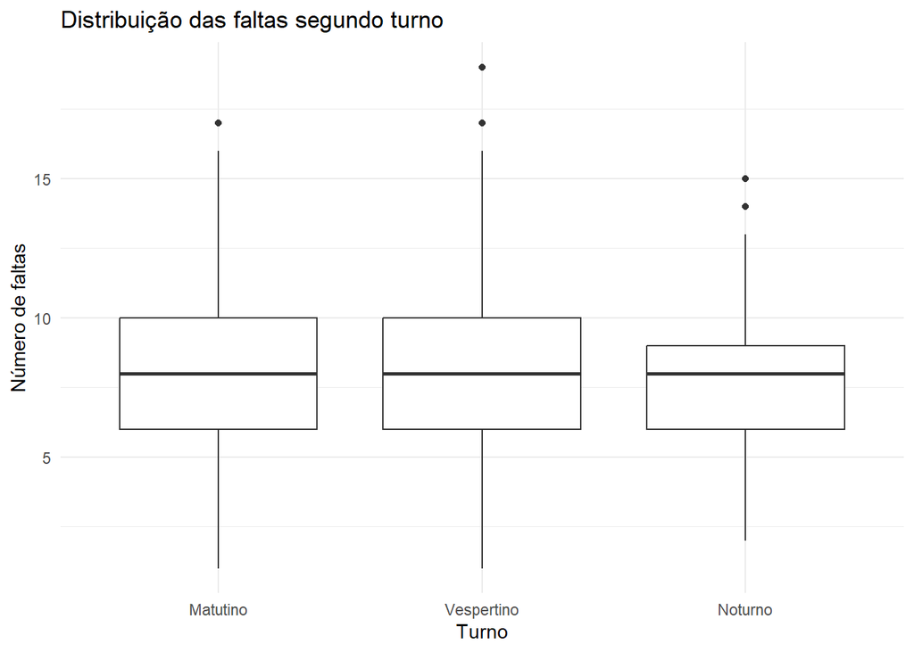

```r
ggplot(
  dados_alunos,
  aes(
    x = turno,
    y = faltas
  )
) +
  geom_boxplot(
    na.rm = TRUE
  ) +
  labs(
    title = "Distribuição das faltas segundo turno",
    x = "Turno",
    y = "Número de faltas"
  ) +
  theme_minimal()
```

# 18 Análise multivariada

A análise multivariada procura avaliar simultaneamente o efeito de diferentes variáveis sobre a nota média.

Será utilizado um modelo de regressão linear múltipla.

O modelo considera:

- faltas;
- turno;
- escolaridade da mãe;
- acesso à internet.

## 18.1 Modelo de regressão

```r
dados_regressao <- dados_alunos[
  complete.cases(
    dados_alunos[
      ,
      c(
        "nota_media",
        "faltas",
        "turno",
        "escolaridade_mae",
        "acesso_internet"
      )
    ]
  ),
]

modelo_regressao <- lm(
  nota_media ~
    faltas +
    turno +
    escolaridade_mae +
    acesso_internet,
  data = dados_regressao
)

summary(modelo_regressao)
```

```
##
## Call:
## lm(formula = nota_media ~ faltas + turno + escolaridade_mae +
##     acesso_internet, data = dados_regressao)
##
## Residuals:
##     Min      1Q  Median      3Q     Max
## -6.0557 -1.2593  0.0225  1.3112  3.8040
##
## Coefficients:
##                     Estimate Std. Error t value Pr(>|t|)
## (Intercept)         6.534384   0.209824  31.142   <2e-16 ***
## faltas             -0.004847   0.021347  -0.227    0.820
## turnoVespertino    -0.123596   0.134681  -0.918    0.359
## turnoNoturno        0.130076   0.159518   0.815    0.415
## escolaridade_mae.L  0.067139   0.128508   0.522    0.601
## escolaridade_mae.Q -0.150025   0.103194  -1.454    0.146
## acesso_internetSim -0.067265   0.130863  -0.514    0.607
## ---
## Signif. codes:  0 '***' 0.001 '**' 0.01 '*' 0.05 '.' 0.1 ' ' 1
##
## Residual standard error: 1.883 on 993 degrees of freedom
## Multiple R-squared:  0.00578,    Adjusted R-squared:  -0.0002277
## F-statistic: 0.9621 on 6 and 993 DF,  p-value: 0.4497
```

## 18.2 Coeficientes do modelo

```r
coeficientes <- as.data.frame(
  summary(modelo_regressao)$coefficients
)

coeficientes$Variavel <- rownames(coeficientes)

rownames(coeficientes) <- NULL

names(coeficientes) <- c(
  "Estimativa",
  "Erro_Padrao",
  "Estatistica_t",
  "P_valor",
  "Variavel"
)

coeficientes <- coeficientes[
  ,
  c(
    "Variavel",
    "Estimativa",
    "Erro_Padrao",
    "Estatistica_t",
    "P_valor"
  )
]

kable(
  coeficientes,
  digits = 4,
  caption = "Coeficientes da regressão linear múltipla"
)
```

Coeficientes da regressão linear múltipla

| Variavel | Estimativa | Erro_Padrao | Estatistica_t | P_valor |
| --- | --- | --- | --- | --- |
| (Intercept) | 6.5344 | 0.2098 | 31.1422 | 0.0000 |
| faltas | -0.0048 | 0.0213 | -0.2271 | 0.8204 |
| turnoVespertino | -0.1236 | 0.1347 | -0.9177 | 0.3590 |
| turnoNoturno | 0.1301 | 0.1595 | 0.8154 | 0.4150 |
| escolaridade_mae.L | 0.0671 | 0.1285 | 0.5225 | 0.6015 |
| escolaridade_mae.Q | -0.1500 | 0.1032 | -1.4538 | 0.1463 |
| acesso_internetSim | -0.0673 | 0.1309 | -0.5140 | 0.6074 |

## 18.3 R² do modelo

```r
resumo_modelo <- summary(modelo_regressao)

r2 <- resumo_modelo$r.squared

r2_ajustado <- resumo_modelo$adj.r.squared

data.frame(
  Medida = c(
    "R²",
    "R² ajustado"
  ),
  Valor = c(
    r2,
    r2_ajustado
  )
) |>
  kable(
    digits = 4,
    caption = "Qualidade de ajuste do modelo"
  )
```

Qualidade de ajuste do modelo

| Medida | Valor |
| --- | --- |
| R² | 0.0058 |
| R² ajustado | -0.0002 |

# 19 Diagnóstico da regressão

Os gráficos abaixo permitem avaliar visualmente os principais pressupostos do modelo de regressão.

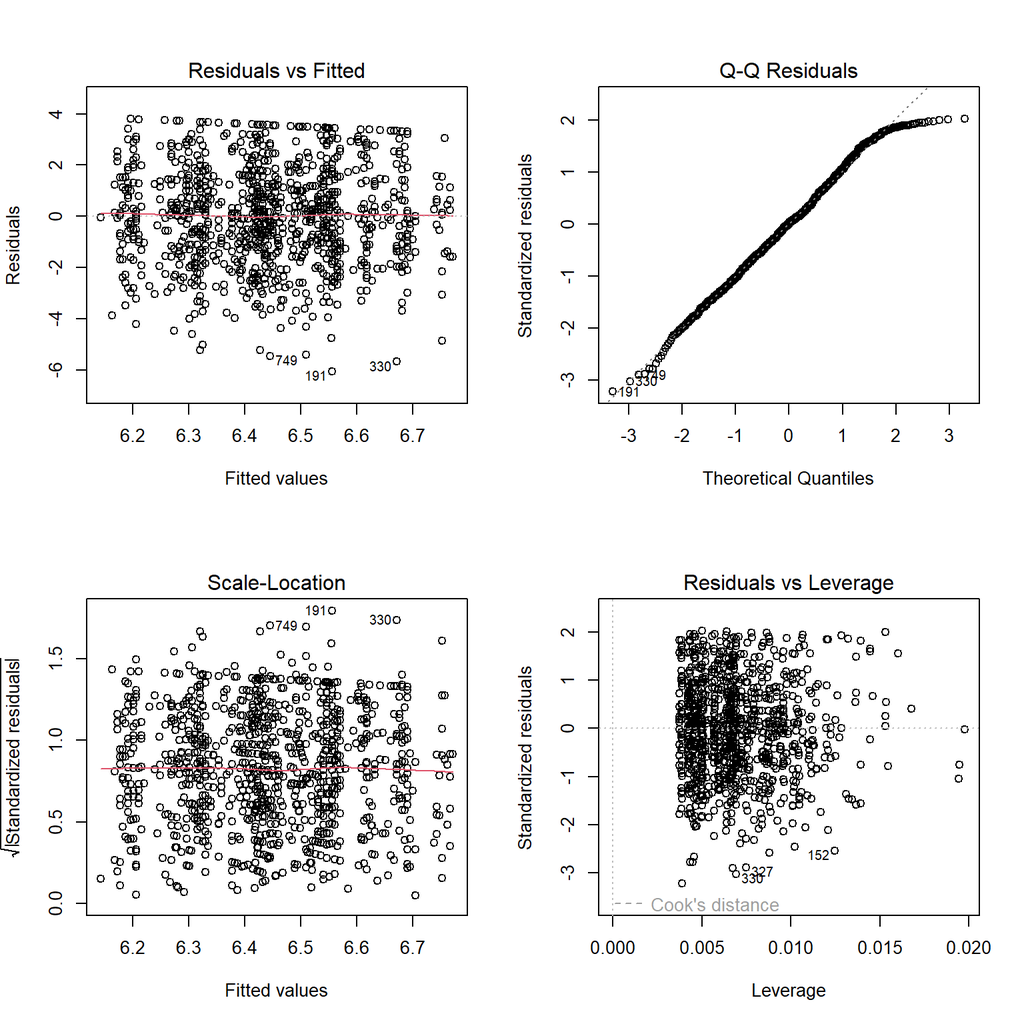

```r
par(
  mfrow = c(2, 2)
)

plot(modelo_regressao)
```

```r
par(
  mfrow = c(1, 1)
)
```

# 20 Turno e acesso à internet

Nesta seção é investigada a associação entre o turno de estudo e o acesso à internet.

## 20.1 Tabela de contingência

```r
tabela_turno_internet <- table(
  dados_alunos$turno,
  dados_alunos$acesso_internet,
  useNA = "no"
)

kable(
  tabela_turno_internet,
  caption = "Turno segundo acesso à internet"
)
```

Turno segundo acesso à internet

|  | Não | Sim |
| --- | --- | --- |
| Matutino | 133 | 318 |
| Vespertino | 107 | 238 |
| Noturno | 57 | 147 |

## 20.2 Percentuais por turno

```r
percentual_turno_internet <- prop.table(
  tabela_turno_internet,
  margin = 1
) * 100

round(
  percentual_turno_internet,
  2
)
```

```
##
##                Não   Sim
##   Matutino   29.49 70.51
##   Vespertino 31.01 68.99
##   Noturno    27.94 72.06
```

## 20.3 Teste qui-quadrado

```r
teste_chi_turno_internet <- chisq.test(
  tabela_turno_internet
)

teste_chi_turno_internet
```

```
##
##  Pearson's Chi-squared test
##
## data:  tabela_turno_internet
## X-squared = 0.59728, df = 2, p-value = 0.7418
```

# 21 Escolaridade da mãe e acesso à internet

Também é analisada a associação entre escolaridade da mãe e acesso à internet.

```r
tabela_mae_internet <- table(
  dados_alunos$escolaridade_mae,
  dados_alunos$acesso_internet,
  useNA = "no"
)

kable(
  tabela_mae_internet,
  caption = "Escolaridade da mãe segundo acesso à internet"
)
```

Escolaridade da mãe segundo acesso à internet

|  | Não | Sim |
| --- | --- | --- |
| Fundamental | 121 | 270 |
| Médio | 124 | 335 |
| Superior | 52 | 98 |

```r
teste_chi_mae_internet <- chisq.test(
  tabela_mae_internet
)

teste_chi_mae_internet
```

```
##
##  Pearson's Chi-squared test
##
## data:  tabela_mae_internet
## X-squared = 3.6476, df = 2, p-value = 0.1614
```

# 22 Turno e escolaridade da mãe

```r
tabela_turno_mae <- table(
  dados_alunos$turno,
  dados_alunos$escolaridade_mae,
  useNA = "no"
)

kable(
  tabela_turno_mae,
  caption = "Turno segundo escolaridade da mãe"
)
```

Turno segundo escolaridade da mãe

|  | Fundamental | Médio | Superior |
| --- | --- | --- | --- |
| Matutino | 168 | 207 | 76 |
| Vespertino | 132 | 157 | 56 |
| Noturno | 91 | 95 | 18 |

```r
teste_chi_turno_mae <- chisq.test(
  tabela_turno_mae
)

teste_chi_turno_mae
```

```
##
##  Pearson's Chi-squared test
##
## data:  tabela_turno_mae
## X-squared = 8.6388, df = 4, p-value = 0.07079
```

# 23 Síntese dos resultados

As análises realizadas permitem avaliar diferentes dimensões relacionadas ao desempenho acadêmico dos estudantes.

A relação entre acesso à internet e desempenho foi analisada por meio da comparação das médias e do teste t de Welch.

A relação entre escolaridade da mãe e desempenho foi avaliada por meio de estatísticas descritivas e análise de variância (ANOVA).

A associação entre faltas e notas foi investigada por meio dos coeficientes de correlação de Pearson e Spearman, além da representação gráfica da relação entre as duas variáveis.

O turno dos estudantes também foi analisado em relação às notas e ao número de faltas.

Por fim, a regressão linear múltipla permitiu analisar simultaneamente o comportamento da nota média em função de faltas, turno, escolaridade da mãe e acesso à internet.

# 24 Conclusões

A análise estatística realizada permite identificar padrões e possíveis associações entre características socioeducacionais e o desempenho dos estudantes.

De modo geral, as conclusões devem ser baseadas nos valores apresentados pelos testes estatísticos, médias, correlações e coeficientes da regressão.

É importante observar que associação estatística não significa necessariamente causalidade. Assim, diferenças encontradas entre grupos devem ser interpretadas como evidências de associação dentro do conjunto de dados analisado.

A análise das faltas possibilita avaliar se maior frequência escolar está relacionada ao desempenho acadêmico.

A comparação entre estudantes com e sem acesso à internet permite avaliar possíveis desigualdades relacionadas ao acesso a recursos tecnológicos.

A escolaridade da mãe fornece uma dimensão socioeducacional importante para avaliar possíveis diferenças no desempenho.

A análise dos turnos permite verificar se existem diferenças no perfil dos estudantes matriculados nos períodos matutino, vespertino e noturno.

# 25 Recomendações

Com base na análise realizada, podem ser consideradas as seguintes recomendações:

1. acompanhar estudantes com elevado número de faltas;
2. identificar estudantes com baixo desempenho acadêmico;
3. ampliar o acesso a recursos tecnológicos e internet quando houver desigualdade de acesso;
4. desenvolver estratégias específicas para estudantes do turno noturno;
5. acompanhar indicadores de desempenho de forma periódica;
6. utilizar os resultados estatísticos como apoio à tomada de decisões educacionais.

# 26 Limitações

Os resultados devem ser interpretados considerando as limitações do conjunto de dados.

A análise estatística identifica associações, mas não permite afirmar causalidade sem um desenho de pesquisa adequado.

Além disso, outras variáveis que podem influenciar o desempenho acadêmico não estão necessariamente presentes no banco de dados.

Portanto, os resultados apresentados devem ser entendidos dentro do contexto específico da amostra analisada.

# 27 Considerações finais

O presente relatório utilizou técnicas de estatística descritiva, análise bivariada e regressão linear múltipla para investigar fatores associados ao desempenho acadêmico.

Foram consideradas variáveis relacionadas às faltas, turno, escolaridade da mãe e acesso à internet.

A combinação dessas análises fornece uma visão mais ampla do perfil dos estudantes e permite identificar possíveis desigualdades e fatores associados ao desempenho.

Os resultados estatísticos apresentados ao longo do relatório devem servir como instrumento de apoio para a interpretação da realidade educacional e para o planejamento de ações que contribuam para a melhoria do desempenho dos estudantes.

[output not shown]